# Discussion 9-Solution: Two independent population tests: The Welch T-Test (with a not equality of variances), Bootstrap test , and The Wilcoxon Rank Sum

# 4 `Step 3`. Check assumptions

Now that we have explored the data, we check the assumptions

- `Are the two samples simple random samples?`

Yes. We know it from the data set information.

- `Do the two populations are independent?`

From the study we can validate this assumption, since the two groups of babies comes from two groups of mothers.

- `Do the two populations birth weight from smoker and non-smoker mother follow a normal distribution?`

The random variables Birth weight of babies born from smoker mothers and non-smokers mothers, are approximately normally-distributed.

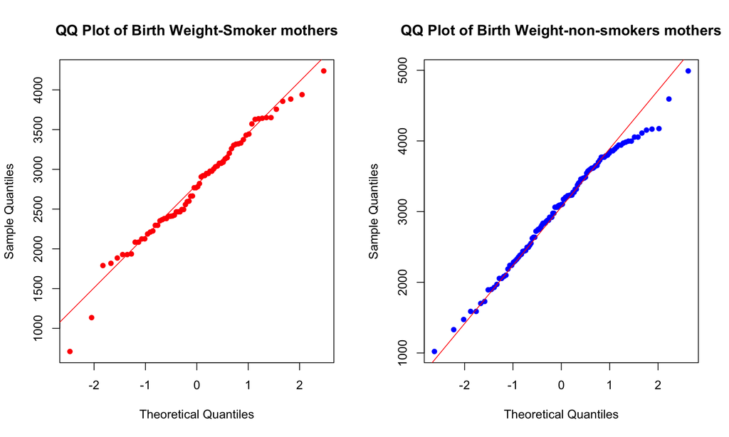

```r
par(mfrow = c(1,2))
qqnorm(slbw$bwt, main = "QQ Plot of Birth Weight-Smoker mothers",col="red",pch=16)
qqline(slbw$bwt,col="red")

qqnorm(nslbw$bwt, main = "QQ Plot of Birth Weight-non-smokers mothers",col="blue",pch=16)
qqline(nslbw$bwt,col="red")
```

Interpretation:

The ‘dip’ below the line for higher birth weights by non-smoker mothers is concerning. By comparing the QQ plot to the histogram, we can see that this is likely caused by some light left-skewness in the non-smoker data. But we can reasonably assume that `both samples of birth weights come from normal populations`.

### 4.0.1 Homogeneity of Variance

The variance of the Birth weight of babies is the same in both groups

- Use the rule of thumb: it is reasonable to assume equal population variances if the ratio of two sample standard deviations is between 0.5 and 2.

```r
sd(slbw$bwt)
```

```
## [1] 659.8075
```

```r
sd(nslbw$bwt)
```

```
## [1] 752.409
```

```r
sd(slbw$bwt)/sd(nslbw$bwt)
```

```
## [1] 0.8769266
```

`Interpretation`

Since the ratio of the two sample standard deviations is between 0.5 and 2, we can assume the two populations of birth weights have equal population variances.

# 5 `Step 4`. Perform the appropriate Test

```r
t.test(slbw$bwt, y =nslbw$bwt,
       alternative = "less",
       mu = 0, paired = FALSE, var.equal = TRUE,
       conf.level = 0.95)
```

```
##
##  Two Sample t-test
##
## data:  slbw$bwt and nslbw$bwt
## t = -2.6428, df = 187, p-value = 0.00446
## alternative hypothesis: true difference in means is less than 0
## 95 percent confidence interval:
##      -Inf -105.859
## sample estimates:
## mean of x mean of y
##  2772.297  3054.957
```

Where

1. `alternative = "less"` since the alternative hypothesis is less than.
2. `mu = 0` since the value under the null hypothesis is 0 $(H_0:\mu_{nsbwt}-\mu_{sbwt}=0)$
3. `paired = FALSE` since the two populations are independent
4. `var.equal = TRUE` since the two populations variance are equal
5. `conf.level = 0.95` since the level of significance is $\alpha=0.05$
- `P value:` The p-value of the test is $p=0.00446$, which is less than $\alpha=0.05$. Thus, we have sufficient evidence to reject the null hypothesis at the $\alpha=0.05$ level
- `Confidence interval:` The $95\%$ one-sided confidence interval for the true difference in mean birth weights for babies born to mothers who smoke and those born to mothers who do not is ($-\infty$, $-105.859$) grams. Since this interval does not include $0$ as a likely value for the true difference in means, we have evidence to reject the null hypothesis at the $\alpha=0.05$ level.

## 5.1 `Step 5`. Write your conclusions

We have enough statistical evidence that babies born from mothers who smoke have lower mean birth weights than those born from non-smoker mothers.

# 6 Problem 2

Situation: Low Birth Weight data set

The data were collected as part of a larger study at Baystate Medical Center in Springfield, Massachusetts. This data set contains information from a simple random sample on 189 births to women seen in the obstetrics clinic. For each mother we are provided with their answer to 10 questions. The information we have is organized into variables. In this case, these 189 mothers are a subset from a larger population of mothers, so we have sample data.

Use a 0.05 significance level to test the claim that the weight (lbs) at last menstrual period (lwt) is different for non-smoker and smoker mothers.

1. State null and alternative hypotheses and the significance level
2. Describe the data

   A. Compute a summary statistic (n, mean, sd, min, and max) for both groups. Interprete your findings.

   B. Present a Graph comparison of the Birth weight (bwt) by variable smoke. Interprete your findings.
3. Check assumptions

   A. Simple random sampling

   B. Independence

   C. Normality

   D. Homogeneity of variance
4. Perform the appropriated Test and make a decision: Use the appropriated R function based on your assumptions.
5. Write your conclusions

# 7 `Step 1`. State null and alternative hypotheses and the significance level

1. `Claim`: “The weight at last menstrual period (lwt) is different for non-smoker and smoker mothers.”
2. The random variables involved in the claim are:

$$\begin{align}
X_{slwt}:&\; \textrm{The weight at last menstrual period for a smoker mothers.}\\
X_{nslwt}:&\; \textrm{The weight at last menstrual period for a non-smoker mothers.}\\
X_{slwt}-X_{nslwt}:&\; \textrm{The mean difference in weight at last menstrual period for a smokers and non-smoker.}
\end{align}$$

`Notice that these variables are quantitative continuous`.

3. The parameter of interest

We will use the notation.

- $\mu_{slwt} =$ The mean weight at last menstrual period for a smoker mothers.
- $\mu_{\textrm{nslwt}} =$ The mean weight at last menstrual period for a non-smoker mothers.

The parameters are

$$\begin{align}
\textrm{Variable}\; X_{slwt}:&\; \textrm{The parameter is}\; \mu_{\textrm{slwt}} \\
\textrm{Variable}\; X_{nslwt}:&\; \textrm{The parameter is}\; \mu_{\textrm{nslwt}} \\
\textrm{Variable}\;X_{slwt}-X_{nslwt}:&\; \textrm{the parameter is}\; \mu_{\textrm{slwt}} - \mu_{\textrm{nslwt}}
\end{align}$$

4. The claim in symbolic form is: $\mu_{\textrm{slwt}} \ne \mu_{\textrm{nslwt}}$ (The weight at last menstrual period (lwt) is different for non-smoker and smoker mothers. )
5. The claim in symbolic form that must be opposite to the original claim is : $\mu_{\textrm{slwt}} = \mu_{\textrm{nslwt}}$
6. The null hypothesis and alternative hypotheses
   $$\bbox[#ffcc99,20px,border:10px ligth red]
   {
   H_{0}: \mu_{\textrm{slwt}} = \mu_{\textrm{nslwt}} \;\;\textrm{vs}\;\;H_{A}: \mu_{\textrm{slwt}} \neq \mu_{\textrm{nslwt}}
   }$$

Or, equivalently:

$$\bbox[#ffcc99,20px,border:10px ligth red]
{
H_{0}: \mu_{\textrm{slwt}} - \mu_{\textrm{nslwt}} = 0 \;\;vs\;\;H_{A}: \mu_{\textrm{slwt}} - \mu_{\textrm{nslwt}} \ne 0
}$$

# 8 `Step 2`. Read and describe the data

- `Data description:` https://vincentarelbundock.github.io/Rdatasets/doc/COUNT/lbw.html

```r
lbw<-read.csv2("Data/lbw.csv",sep=",", dec = ".")
lbw$low<-as.factor(lbw$low)
lbw$smoke<-as.factor(lbw$smoke)
lbw$race<-as.factor(lbw$race)
lbw$ht<-as.factor(lbw$ht)
lbw$ui<-as.factor(lbw$ui)

str(lbw)
```

```
## 'data.frame':    189 obs. of  11 variables:
##  $ ID   : int  1 2 3 4 5 6 7 8 9 10 ...
##  $ low  : Factor w/ 2 levels "0","1": 1 1 1 1 1 1 1 1 1 1 ...
##  $ smoke: Factor w/ 2 levels "0","1": 1 1 2 2 2 1 1 1 2 2 ...
##  $ race : Factor w/ 3 levels "1","2","3": 2 3 1 1 1 3 1 3 1 1 ...
##  $ age  : int  19 33 20 21 18 21 22 17 29 26 ...
##  $ lwt  : int  182 155 105 108 107 124 118 103 123 113 ...
##  $ ptl  : int  0 0 0 0 0 0 0 0 0 0 ...
##  $ ht   : Factor w/ 2 levels "0","1": 1 1 1 1 1 1 1 1 1 1 ...
##  $ ui   : Factor w/ 2 levels "0","1": 2 1 1 2 2 1 1 1 1 1 ...
##  $ ftv  : int  0 3 1 2 0 0 1 1 1 0 ...
##  $ bwt  : int  2523 2551 2557 2594 2600 2622 2637 2637 2663 2665 ...
```

- Split the data: Split the dataset in R using the function `subset()`. Let the data vectors:

`slwt:` weight at last menstrual period for a smoker mothers.

`nslwt:` weight at last menstrual period for a non-smoker mothers.

```r
slwt<-subset(lbw, smoke == 1)
nslwt<-subset(lbw, smoke == 0)
```

A. Compute a summary statistic (n, mean, sd, min, and max) for both groups

```r
length(slwt$lwt)
```

```
## [1] 74
```

```r
length(nslwt$lwt)
```

```
## [1] 115
```

```r
summary(slwt$lwt)
```

```
##    Min. 1st Qu.  Median    Mean 3rd Qu.    Max.
##    80.0   107.2   120.0   128.1   137.2   250.0
```

```r
summary(nslwt$lwt)
```

```
##    Min. 1st Qu.  Median    Mean 3rd Qu.    Max.
##    85.0   112.0   124.0   130.9   141.5   241.0
```

```r
sd(slwt$lwt)
```

```
## [1] 33.78673
```

```r
sd(nslwt$lwt)
```

```
## [1] 28.41916
```

|  | Smoker Mother | Non-Smoker Mother |
| --- | --- | --- |
| Mean | 128.1 | 130.9 |
| Standard Deviation | 33.79 | 28.42 |
| Median | 120.0 | 124.0 |
| Minimum | 80.0 | 85.0 |
| Maximum | 250.0 | 241.0 |
| n | 74 | 115 |

`Interpretation:`

B. Present a Graphical comparison of the weight at last menstrual period by the variable smoke

- Use the same scale for both histogram: use $summary(slwt\$bwt)$ and $summary(nslwt\$bwt)$ functions to determine the minimum between the two minimums, and the maximum between the two maximums. Then include as an histogram argument: `xlim = c(80,250)`

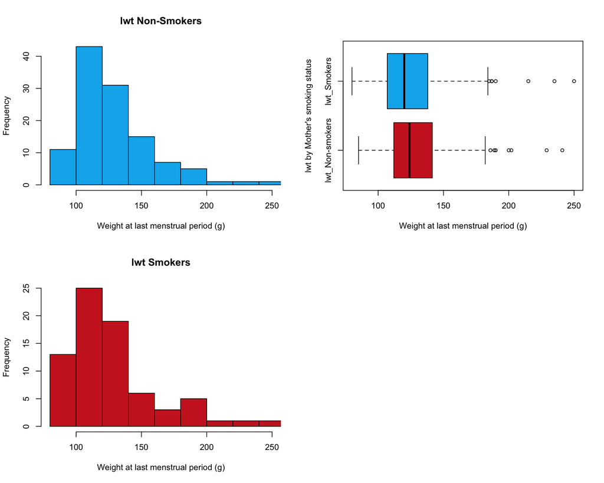

```r
par(mfrow = c(2,2))

hist(nslwt$lwt,main="lwt Non-Smokers" ,xlim = c(80,250),
     xlab = "Weight at last menstrual period (g)",col="deepskyblue2")

boxplot(lbw$lwt~lbw$smoke,horizontal = TRUE,names=c("lwt_Non-smokers", "lwt_Smokers"),
        xlab = "Weight at last menstrual period (g)",ylab="lwt by Mother's smoking status",
        col=c("firebrick3","deepskyblue2"))


hist(slwt$lwt, main="lwt Smokers",xlim = c(80,250),
     xlab = "Weight at last menstrual period (g)",col="firebrick3")
```

`Interpretation:`

# 9 `Step 3`. Check assumptions

Now that we have explored the data, we check the assumptions

- `Are the two samples simple random samples?`

Yes. We know it from the data set information.

- `Do the two populations weight at last menstrual period from smoker and non-smoker mothers are independent?`

From the study we can validate this assumption, since we have two groups of mothers: smokers and non-smokers. Our observation are not paired or matched.

- `Do the two populations weight at last menstrual period from smoker and non-smoker mothers follow a normal distribution?`

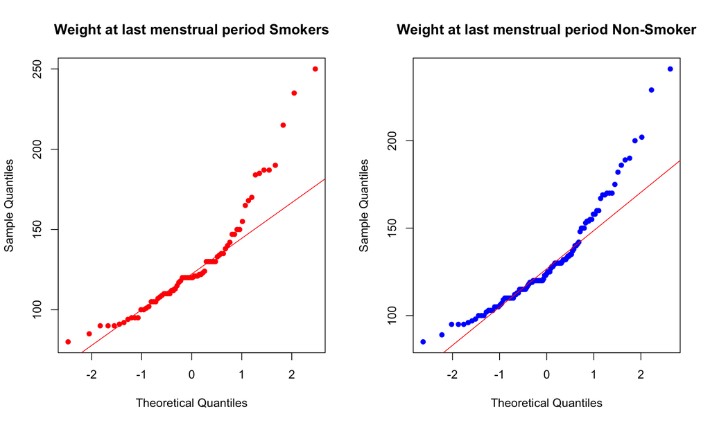

```r
par(mfrow = c(1,2))
qqnorm(slwt$lwt, main = "Weight at last menstrual period Smokers",col="red",pch=16)
qqline(slwt$lwt,col="red")

qqnorm(nslwt$lwt, main = "Weight at last menstrual period Non-Smoker",col="blue",pch=16)
qqline(nslwt$lwt,col="red")
```

`Interpretation:`

We observe that the points do not fit well the straight line both for the qq plot from data of smokers and non-smoker mothers. By comparing the QQ plot to the histogram, we can see that this is likely caused by some light right-skewness in the smoker and non-smoker data. But we cannot reasonably assume that `both samples of weights at last menstrual period come from normal populations`.

## 9.1 D. Homogeneity of Variance

The variance of the weights at last menstrual period is the same in both groups.

- Use the rule of thumb: it is reasonable to assume equal population variances if the ratio of two sample standard deviations is between 0.5 and 2.

```r
sd(slwt$lwt)
```

```
## [1] 33.78673
```

```r
sd(nslwt$lwt)
```

```
## [1] 28.41916
```

```r
sd(slwt$lwt)/sd(nslwt$lwt)
```

```
## [1] 1.188872
```

`Interpretation`

Since the ratio of the two sample standard deviations is between 0.5 and 2, we can assume the two populations of weights at last menstrual period have equal population variances.

# 10 `Step 4`. Perform the appropriate Test

- We have evidence from the qq plots that that the variables `slwt`: weight at last menstrual period for mothers who reported smoking and `nslwt`: weight at last menstrual period for mothers who reported not smoking are non-normal.
- The sample size in both variables (slwt: 74 and nslwt: 115) are large enough that the Central Limit Theorem would probably make $\bar{X}_{slwt}$ and $\bar{X}_{nslwt}$ approximately normal.

On the other hand, since our samples do not come from normal distribution we would tend to `perform a bootstrap t` and report the more conservative.

## 10.1 t-test

```r
t.test(slwt$lwt, y =nslwt$lwt,
       alternative = "two.sided",
       mu = 0, paired = FALSE, var.equal = TRUE,
       conf.level = 0.95)
```

```
##
##  Two Sample t-test
##
## data:  slwt$lwt and nslwt$lwt
## t = -0.60672, df = 187, p-value = 0.5448
## alternative hypothesis: true difference in means is not equal to 0
## 95 percent confidence interval:
##  -11.77318   6.23475
## sample estimates:
## mean of x mean of y
##  128.1351  130.9043
```

## 10.2 bootstrap t

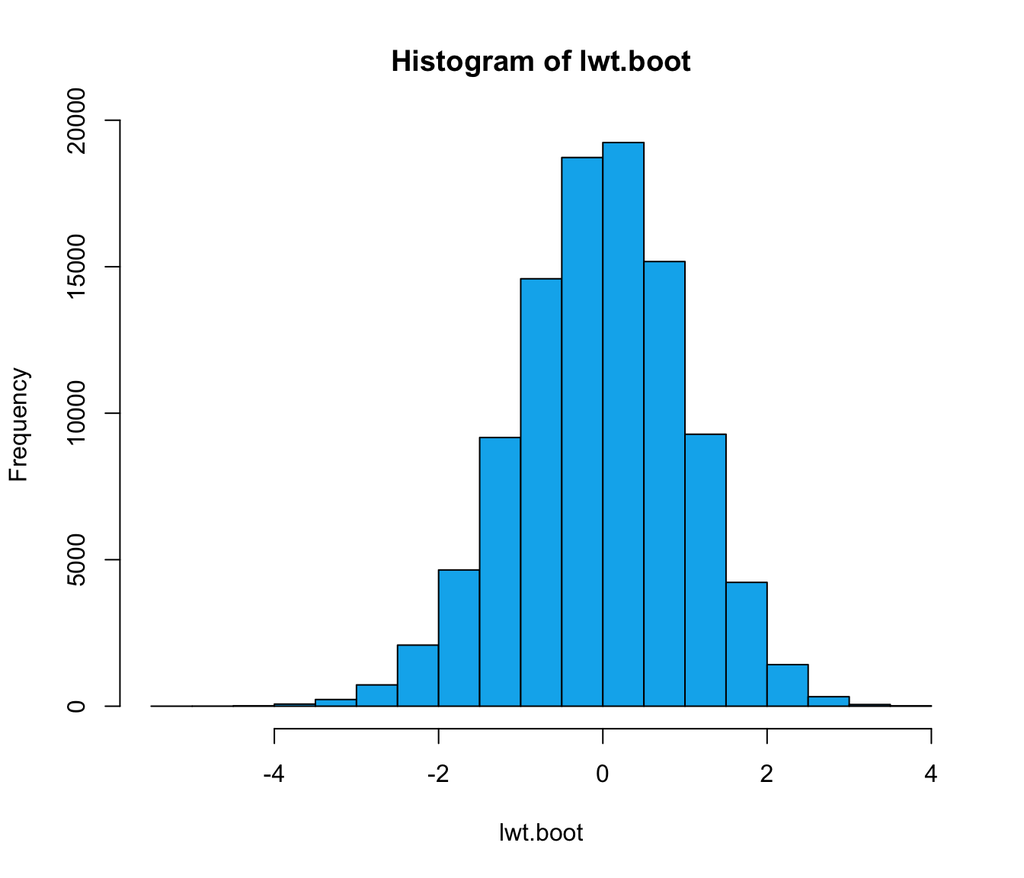

```r
# Here's one way to do the bootstrap for a difference of two means in R:
# dat1 and dat2 are data from the two groups. nboot is the number of resamples.
# Notice obsdiff is computed as mean(dat1)-mean(dat2) - order matters!

boottwo = function(data1, data2, nboot) {
  bootstat = numeric(nboot)
  obsdiff = mean(data1) - mean(data2)
  n1 = length(data1)
  n2 = length(data2)
  for(i in 1:nboot) {
    sample1 = sample(data1, size = n1, replace = TRUE)
    sample2 = sample(data2, size = n2, replace = TRUE)
    bootmean1 = mean(sample1)
    bootmean2 = mean(sample2)
    bootvar1 = var(sample1)
    bootvar2 = var(sample2)
    bootstat[i] = ((bootmean1 - bootmean2) - obsdiff)/sqrt((bootvar1/n1) + (bootvar2/n2))
}
  return(bootstat)
}

#Here's how you can save of the individual lwt vectors from the lbw data frame:

slwt=subset(lbw, smoke=="1") # lbw data for smoker mothers
nslwt=subset(lbw, smoke=="0") # lbw data for non-smoker mothers



set.seed(1) # to make reproducible the results
lwt.boot<-boottwo(slwt$lwt, nslwt$lwt, nboot=100000)
hist(lwt.boot,col="deepskyblue2")
```

```r
boo.t.lower<-quantile(lwt.boot,probs = .05)
boo.t.upper<-quantile(lwt.boot,probs = .95)

obs.diff<-(mean(slwt$lwt)-mean(slwt$lwt))
obs.se<-sqrt(var(slwt$lwt)/length(slwt$lwt)+var(slwt$lwt)/length(nslwt$lwt))

(ci.lower<-obs.diff-boo.t.upper*obs.se)
```

```
##       95%
## -7.996425
```

```r
(ci.upper<-obs.diff-boo.t.lower*obs.se)
```

```
##       5%
## 8.827363
```

## 10.3 `Step 5`. Write your conclusions

There were not statistical significant differences between the weigh at last menstrual period from groups of smoker and non-smoker mothers.